# The Recividism rate

Keith Tung

April 2, 2019

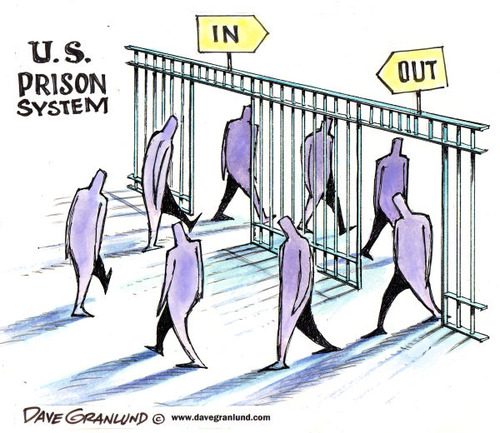

```r
################################library##############################################
library(tidyverse)
library(readr)
library(ggplot2)
library(ggridges)
library(pander)
library(caret)
################################Read File############################################
dat_o <- read.csv('https://raw.githubusercontent.com/propublica/compas-analysis/master/compas-scores-two-years.csv')
dat <- read_csv('./dt_dat.csv')
rdat <- read_csv('./dt.csv') %>% select(-1)
frdat <- read_csv('./fr_race.csv') %>% select(-1)
fdat <- read_csv('./frw_race.csv') %>% select(-1)
dat_nnn <- read_csv('Song/race2.csv')
```

### Team Info

1. Team members: Keaton Sant, Keith Tung, Juheon Song
2. Data source: Data source: Machine bias https://github.com/propublica/compas-analysis/blob/master/compas-scores-two-years.csv

# Introduction

### The source

This project is mainly inspired by a statistical study online; in this study, the narrator introduces the reader to an algorithm the justice system in the US is currently using. This algorithm takes in criminal information such as age, gender, race, and criminal records then produces a score for the person’s ‘risk of recidivism’ which would be provided as reference to the judge in deciding the sentence of a criminal; the study contains arguments with various plots and charts that surround the same claim : the algorithm is biased against black criminal.

### Our take

We, as a team, chose to investigate this data that recorded inmates’ information that was used to predict the criminals’ recidivism rate before they were sentenced jail time. This data set shows a column with the predicted score and whether these individuals ended up committing a crime again in the 2 year period after they were released from jail.

### Our Goals

There are two main goals for our project:

- Examine the claim made by the study, see that the current algorithm is biased
- Try to create an algorithm hoping to see if race is indeed a helpful variable in predicting recidivism rate.

# Data Preparation

### Understanding the data

There are a few observations from the data.

#### Column Descriptions

sex: The gender of each criminal; numerically set as 1 (Male) and 0 (Female).

age: The age of each criminal when they when they were screened.

age_cat: Criminals are seperated into three age brackets; less than 25, 25 - 45, greater than 45.

juv_fel_count: The number of juvenile felonies each criminal has.

juv_misd_count: The number of Juvenile misdemeanors each criminal has.

juv_other_count: The number of other juvenile offenses the criminal has.

priors_count: The number of prior crimes committed before aprehended.

c_charge_degree: Were they charged for a felony or misdemeanor when they were arrested?

c_charge_desc: The description of each charge is listed below.

two_year_recid (Target Feature): Were they arrested for committing a crime within two years after they were released from prison? 1 (yes) and 0 (no).

### Observation

#### The converting

To accomplish our tasks, we needed the data to fit in five different machine learning algorithms, namely, Naïve Bayes (classifier), Decision tree (classifier), Neural Network (classifier), K Nearest Neighbor (Classifier), and stacking. The data set contains numeric and categorical columns with the binary target column “recidivist or non-recidivist”.

#### Original data(sample of 5)

```r
pander(dat_o %>% head(5))
```

Table continues below

| id | name | first | last | compas_screening_date | sex |
| --- | --- | --- | --- | --- | --- |
| 1 | miguel hernandez | miguel | hernandez | 2013-08-14 | Male |
| 3 | kevon dixon | kevon | dixon | 2013-01-27 | Male |
| 4 | ed philo | ed | philo | 2013-04-14 | Male |
| 5 | marcu brown | marcu | brown | 2013-01-13 | Male |
| 6 | bouthy pierrelouis | bouthy | pierrelouis | 2013-03-26 | Male |

Table continues below

| dob | age | age_cat | race | juv_fel_count |
| --- | --- | --- | --- | --- |
| 1947-04-18 | 69 | Greater than 45 | Other | 0 |
| 1982-01-22 | 34 | 25 - 45 | African-American | 0 |
| 1991-05-14 | 24 | Less than 25 | African-American | 0 |
| 1993-01-21 | 23 | Less than 25 | African-American | 0 |
| 1973-01-22 | 43 | 25 - 45 | Other | 0 |

Table continues below

| decile_score | juv_misd_count | juv_other_count | priors_count |
| --- | --- | --- | --- |
| 1 | 0 | 0 | 0 |
| 3 | 0 | 0 | 0 |
| 4 | 0 | 1 | 4 |
| 8 | 1 | 0 | 1 |
| 1 | 0 | 0 | 2 |

Table continues below

| days_b_screening_arrest | c_jail_in | c_jail_out |
| --- | --- | --- |
| -1 | 2013-08-13 06:03:42 | 2013-08-14 05:41:20 |
| -1 | 2013-01-26 03:45:27 | 2013-02-05 05:36:53 |
| -1 | 2013-04-13 04:58:34 | 2013-04-14 07:02:04 |
| NA |  |  |
| NA |  |  |

Table continues below

| c_case_number | c_offense_date | c_arrest_date | c_days_from_compas |
| --- | --- | --- | --- |
| 13011352CF10A | 2013-08-13 |  | 1 |
| 13001275CF10A | 2013-01-26 |  | 1 |
| 13005330CF10A | 2013-04-13 |  | 1 |
| 13000570CF10A | 2013-01-12 |  | 1 |
| 12014130CF10A |  | 2013-01-09 | 76 |

Table continues below

| c_charge_degree | c_charge_desc | is_recid | r_case_number |
| --- | --- | --- | --- |
| F | Aggravated Assault w/Firearm | 0 |  |
| F | Felony Battery w/Prior Convict | 1 | 13009779CF10A |
| F | Possession of Cocaine | 1 | 13011511MM10A |
| F | Possession of Cannabis | 0 |  |
| F | arrest case no charge | 0 |  |

Table continues below

| r_charge_degree | r_days_from_arrest | r_offense_date |
| --- | --- | --- |
|  | NA |  |
| (F3) | NA | 2013-07-05 |
| (M1) | 0 | 2013-06-16 |
|  | NA |  |
|  | NA |  |

Table continues below

| r_charge_desc | r_jail_in | r_jail_out | violent_recid |
| --- | --- | --- | --- |
|  |  |  | NA |
| Felony Battery (Dom Strang) |  |  | NA |
| Driving Under The Influence | 2013-06-16 | 2013-06-16 | NA |
|  |  |  | NA |
|  |  |  | NA |

Table continues below

| is_violent_recid | vr_case_number | vr_charge_degree | vr_offense_date |
| --- | --- | --- | --- |
| 0 |  |  |  |
| 1 | 13009779CF10A | (F3) | 2013-07-05 |
| 0 |  |  |  |
| 0 |  |  |  |
| 0 |  |  |  |

Table continues below

| vr_charge_desc | type_of_assessment | decile_score.1 | score_text |
| --- | --- | --- | --- |
|  | Risk of Recidivism | 1 | Low |
| Felony Battery (Dom Strang) | Risk of Recidivism | 3 | Low |
|  | Risk of Recidivism | 4 | Low |
|  | Risk of Recidivism | 8 | High |
|  | Risk of Recidivism | 1 | Low |

Table continues below

| screening_date | v_type_of_assessment | v_decile_score | v_score_text |
| --- | --- | --- | --- |
| 2013-08-14 | Risk of Violence | 1 | Low |
| 2013-01-27 | Risk of Violence | 1 | Low |
| 2013-04-14 | Risk of Violence | 3 | Low |
| 2013-01-13 | Risk of Violence | 6 | Medium |
| 2013-03-26 | Risk of Violence | 1 | Low |

Table continues below

| v_screening_date | in_custody | out_custody | priors_count.1 | start | end |
| --- | --- | --- | --- | --- | --- |
| 2013-08-14 | 2014-07-07 | 2014-07-14 | 0 | 0 | 327 |
| 2013-01-27 | 2013-01-26 | 2013-02-05 | 0 | 9 | 159 |
| 2013-04-14 | 2013-06-16 | 2013-06-16 | 4 | 0 | 63 |
| 2013-01-13 |  |  | 1 | 0 | 1174 |
| 2013-03-26 |  |  | 2 | 0 | 1102 |

| event | two_year_recid |
| --- | --- |
| 0 | 0 |
| 1 | 1 |
| 0 | 1 |
| 0 | 0 |
| 0 | 0 |

#### Data after wrangling(Categorical)

```r
pander(dat %>% head(5))
```

Table continues below

| sex | age_cat | race | juv_fel_count | juv_misd_count |
| --- | --- | --- | --- | --- |
| Male | Greater than 45 | FALSE | None | None |
| Male | 25 - 45 | TRUE | None | None |
| Male | Less than 25 | TRUE | None | None |
| Male | Less than 25 | TRUE | None | 1 to 2 |
| Male | 25 - 45 | FALSE | None | None |

Table continues below

| juv_other_count | priors_count | c_charge_degree |
| --- | --- | --- |
| None | None | F |
| None | None | F |
| 1 to 2 | 1 to 5 | F |
| None | 1 to 5 | F |
| None | 1 to 5 | F |

| c_charge_desc | two_year_recid |
| --- | --- |
| Aggravated Assault w/Firearm | 0 |
| Felony Battery w/Prior Convict | 1 |
| Possession of Cocaine | 1 |
| Possession of Cannabis | 0 |
| arrest case no charge | 0 |

#### Data after wrangleing(Numeric)

```r
pander(dat_nnn %>% head(5))
```

Table continues below

| sex | age | race | juv_fel_count | juv_misd_count | juv_other_count |
| --- | --- | --- | --- | --- | --- |
| 1 | 69 | 1 | 0 | 0 | 0 |
| 1 | 34 | 0 | 0 | 0 | 0 |
| 1 | 24 | 0 | 0 | 0 | 1 |
| 1 | 23 | 0 | 0 | 1 | 0 |
| 1 | 43 | 1 | 0 | 0 | 0 |

| priors_count | c_charge_degree | c_charge_desc | two_year_recid |
| --- | --- | --- | --- |
| 0 | 0 | 1 | 0 |
| 0 | 0 | 2 | 1 |
| 4 | 0 | 3 | 1 |
| 1 | 0 | 4 | 0 |
| 2 | 0 | 5 | 0 |

### Decisions made

#### Charges

One of the challenges of the data is the c_charge_desc that stores the description of the crime for what the inmate was charged; there were 437 different charges description in our data with over 7000 observations. We had to do a local encoding for each of them for the Neural Network models.

#### List of charges

```r
dat_o$c_charge_desc %>%
  unique()
```

```
##   [1] Aggravated Assault w/Firearm
##   [2] Felony Battery w/Prior Convict
##   [3] Possession of Cocaine
##   [4] Possession of Cannabis
##   [5] arrest case no charge
##   [6] Battery
##   [7] Possession Burglary Tools
##   [8] Insurance Fraud
##   [9] Poss 3,4 MDMA (Ecstasy)
##  [10] Poss3,4 Methylenedioxymethcath
##  [11] Felony Driving While Lic Suspd
##  [12] Grand Theft in the 3rd Degree
##  [13] Driving While License Revoked
##  [14] Possession Of Heroin
##  [15] Battery on Law Enforc Officer
```

[output cut: 424 more lines]

# Mining/learning from the data

### Data analysis

#### 1

The graph shows the density of the predicted score from the algorithm. We can see that in all three age groups, african-americans have a higher density beyond the 5.0 score; with non-african-american criminals having distributions closing to the other end. It also shows the differences among the age group, while the algorithm is fairly willing to give a low score to someone in the ‘Greater than 45’ group; it tends to give a higher score to people that are in the less than 25 more than the other two.

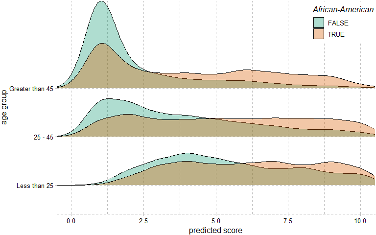

```r
dat_o %>%
  mutate(age_cat = fct_relevel(age_cat,
                               c('Less than 25',
                                 '25 - 45',
                                 'Greater than 45'))) %>%
  ggplot() +
  aes(y = age_cat,
      x = dat_o$decile_score.1,
      fill = (race == 'African-American')) +
  geom_density_ridges(panel_scaling = F,
                       alpha = 0.35) +
  coord_cartesian(xlim = c(0,10)) +
  scale_fill_brewer(palette = 'Dark2') +
  ggthemes::theme_pander() +
  labs(x = 'predicted score',
       y = 'age group') +
  guides(fill = guide_legend(title = 'African-American', label.position = 'right')) +
  theme(axis.line.x = element_line(linetype = 'dashed', colour = 'Gray'),
        legend.position = c(0.9,0.9))
```

#### 2

The histograms show the predicted scores from the algorithm. Each bar’s color presents if they are recidivist or not. The recidivist bar should distribute to score of 10, and not recidivist bar should place to score of 0 based on the algorithm. In the other races’ plot, we can see that most of the not recidivist criminals of other races are distributed between 0 to 2, and it gets decreased as the predicted scores go higher. However, the recidivist bars go low like not recidivist bars. This states that the algorithm tends to distribute criminals of the other races who are not recidivists. The African American histogram shows that there are more African American recidivists than in the plot of the other races. It is interesting to see how much of the differences there is between African American than all the other races combined.

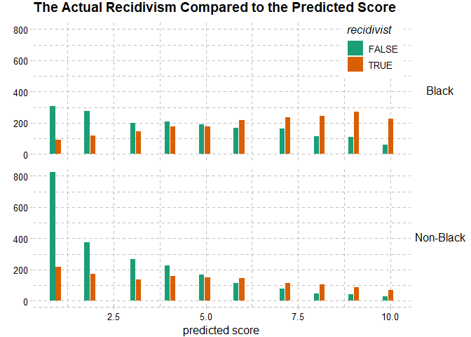

```r
dat_o %>%
  mutate(sep = case_when(
    race == 'African-American' ~ 'Black',
    race != 'African-American' ~ 'Non-Black'
  )) %>%
  ggplot() +
  aes(x = dat_o$decile_score.1, fill = dat_o$two_year_recid == 1) +
  geom_histogram(position = 'dodge_2') +
  facet_grid(sep~.) +
  ggthemes::theme_pander() +
  theme(strip.text.y = element_text(size = 12, angle = 0),
        strip.background = element_blank()) +
  scale_fill_brewer(palette = 'Dark2') +
  guides(fill = guide_legend(title = 'recidivist', label.position = 'right')) +
  labs(title = 'The Actual Recidivism Compared to the Predicted Score', x = 'predicted score', y = '') +
  theme(axis.line.x = element_line(linetype = 'dashed', colour = 'Gray'),
        legend.position = c(0.9,0.9))
```